# EasyVisa_Full_Code_Project

### Data Preparation for modeling

```python
# Copia do DataFrame original sem o identificador
df_model = df.drop('case_id', axis=1)

# Codificação da variável alvo: 1 para 'Certified', 0 caso contrário
df_model['case_status'] = df_model['case_status'].apply(lambda x: 1 if x == 'Certified' else 0)

# Separando features e target
X = df_model.drop('case_status', axis=1)
y = df_model['case_status']

# Identificar colunas
categorical_cols = ['continent', 'education_of_employee', 'has_job_experience',
                    'requires_job_training', 'region_of_employment',
                    'unit_of_wage', 'full_time_position']
numeric_cols = ['prevailing_wage', 'no_of_employees', 'yr_of_estab']

# Divisão treino/teste com estratificação
X_train, X_test, y_train, y_test = train_test_split(
    X, y, test_size=0.3, random_state=42, stratify=y
)

# Criando o transformador com OneHotEncoder para categóricas e StandardScaler para numéricas
preprocessor = ColumnTransformer(
    transformers=[
        ('num', StandardScaler(), numeric_cols),
        ('cat', OneHotEncoder(drop='first', handle_unknown='ignore'), categorical_cols)
    ]
)

# Aplicar o pré-processamento nos dados
X_train = preprocessor.fit_transform(X_train)
X_test = preprocessor.transform(X_test)

num_features = numeric_cols
cat_encoder = preprocessor.named_transformers_['cat']
cat_features = cat_encoder.get_feature_names_out(categorical_cols)
feature_names = list(num_features) + list(cat_features)

# Exibindo formas e distribuição
print(f"Training set shape: {X_train.shape}")
print(f"Test set shape: {X_test.shape}")
print(f"Target variable distribution in training set:\n{y_train.value_counts(normalize=True)}")
```

```
Training set shape: (17836, 21)
Test set shape: (7644, 21)
Target variable distribution in training set:
case_status
1    0.667919
0    0.332081
Name: proportion, dtype: float64
```

## Model Building

### Model Evaluation Criterion

In any predictive model, especially one related to visa approval, incorrect predictions can happen in two key ways:

1. The model predicts that a visa will be approved, but in reality, it should have been denied.
2. The model predicts that a visa will be denied, but it actually should have been approved.

Both scenarios are critical and carry significant consequences.

- In the first case, approving a visa that should be denied might result in hiring someone who doesn't meet the necessary criteria, potentially displacing a U.S. worker who could have taken the position.
- In the second case, denying a visa that should have been approved means losing a qualified professional who could contribute valuable skills to the workforce and the broader economy.

Minimizing These Risks

To reduce the impact of both false positives and false negatives, it's important to evaluate the model using a metric that balances precision and recall. That’s why I’ve chosen to focus on the F1 Score, as it ensures the model doesn’t favor one type of error over the other but instead seeks an optimal balance between them.

```python
# defining a function to compute different metrics to check performance of a classification model built using sklearn


def model_performance_classification_sklearn(model, predictors, target):
    """
    Function to compute different metrics to check classification model performance

    model: classifier
    predictors: independent variables
    target: dependent variable
    """

    # predicting using the independent variables
    pred = model.predict(predictors)

    acc = accuracy_score(target, pred)  # to compute Accuracy
    recall = recall_score(target, pred)  # to compute Recall
    precision = precision_score(target, pred)  # to compute Precision
    f1 = f1_score(target, pred)  # to compute F1-score

    # creating a dataframe of metrics
    df_perf = pd.DataFrame(
        {"Accuracy": acc, "Recall": recall, "Precision": precision, "F1": f1,},
        index=[0],
    )

    return df_perf
```

```python
def confusion_matrix_sklearn(model, predictors, target):
    """
    To plot the confusion_matrix with percentages

    model: classifier
    predictors: independent variables
    target: dependent variable
    """
    y_pred = model.predict(predictors)
    cm = confusion_matrix(target, y_pred)
    labels = np.asarray(
        [
            ["{0:0.0f}".format(item) + "\n{0:.2%}".format(item / cm.flatten().sum())]
            for item in cm.flatten()
        ]
    ).reshape(2, 2)

    plt.figure(figsize=(6, 4))
    sns.heatmap(cm, annot=labels, fmt="")
    plt.ylabel("True label")
    plt.xlabel("Predicted label")
```

#### Defining scorer to be used for cross-validation and hyperparameter tuning

**We are now done with pre-processing and evaluation criterion, so let's start building the model.**

### Model building with original data

```python
# Creating a list of models to test
models = {
    "Logistic Regression": LogisticRegression(random_state=42, max_iter=1000),
    "Decision Tree": DecisionTreeClassifier(random_state=42),
    "Random Forest": RandomForestClassifier(random_state=42),
    "XGBoost": XGBClassifier(random_state=42)
}
```

```
Training model: Logistic Regression
Performance on the test set:
```

|  | Accuracy | Recall | Precision | F1 |
| --- | --- | --- | --- | --- |
| 0 | 0.731554 | 0.875024 | 0.759565 | 0.813217 |

```
Training model: Decision Tree
Performance on the test set:
```

|  | Accuracy | Recall | Precision | F1 |
| --- | --- | --- | --- | --- |
| 0 | 0.650968 | 0.735749 | 0.740099 | 0.737917 |

```
Training model: Random Forest
Performance on the test set:
```

|  | Accuracy | Recall | Precision | F1 |
| --- | --- | --- | --- | --- |
| 0 | 0.715594 | 0.834084 | 0.762399 | 0.796632 |

```
Training model: XGBoost
Performance on the test set:
```

|  | Accuracy | Recall | Precision | F1 |
| --- | --- | --- | --- | --- |
| 0 | 0.72763 | 0.85191 | 0.766344 | 0.806865 |

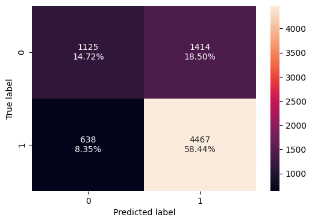

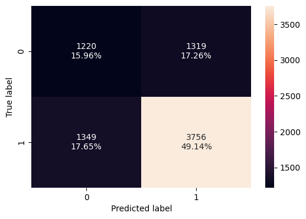

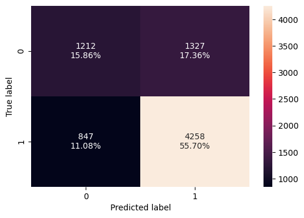

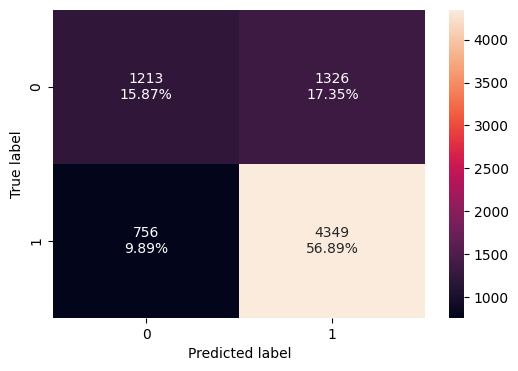

```python
# Training and evaluating each model
results = {}
for name, model in models.items():
    print(f"\nTraining model: {name}")
    model.fit(X_train, y_train)

    # Evaluating on the test set
    test_perf = model_performance_classification_sklearn(model, X_test, y_test)
    results[name] = test_perf

    print("Performance on the test set:")
    display(test_perf)

    # Plotting the confusion matrix
    confusion_matrix_sklearn(model, X_test, y_test)
```

```python
# Combining results into a single DataFrame
all_results = pd.concat([result.assign(Model=name) for name, result in results.items()])
all_results = all_results[['Model', 'Accuracy', 'Precision', 'Recall', 'F1']]
```

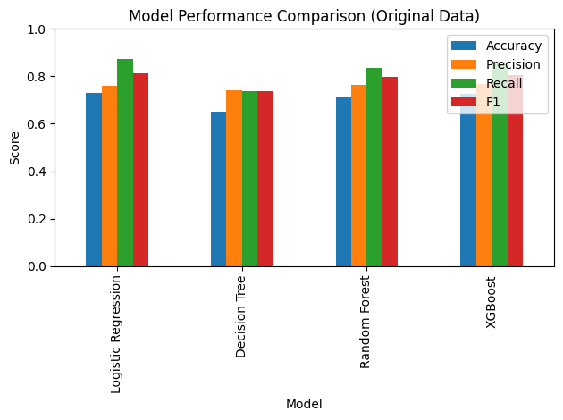

```python
# Visualizing model performance comparison
plt.figure(figsize=(12, 8))
all_results.set_index('Model').plot(kind='bar')
plt.title('Model Performance Comparison (Original Data)')
plt.ylabel('Score')
plt.ylim(0, 1)
plt.tight_layout()
plt.show()
```

### Model Building with oversampled data

```
Training model with SMOTE: Logistic Regression
Performance on the test set:
```

|  | Accuracy | Recall | Precision | F1 |
| --- | --- | --- | --- | --- |
| 0 | 0.692177 | 0.705583 | 0.809075 | 0.753793 |

```
Training model with SMOTE: Decision Tree
Performance on the test set:
```

|  | Accuracy | Recall | Precision | F1 |
| --- | --- | --- | --- | --- |
| 0 | 0.640241 | 0.695984 | 0.747843 | 0.720982 |

```
Training model with SMOTE: Random Forest
Performance on the test set:
```

|  | Accuracy | Recall | Precision | F1 |
| --- | --- | --- | --- | --- |
| 0 | 0.700157 | 0.762586 | 0.782827 | 0.772574 |

```
Training model with SMOTE: XGBoost
Performance on the test set:
```

|  | Accuracy | Recall | Precision | F1 |
| --- | --- | --- | --- | --- |
| 0 | 0.718995 | 0.786288 | 0.79156 | 0.788915 |

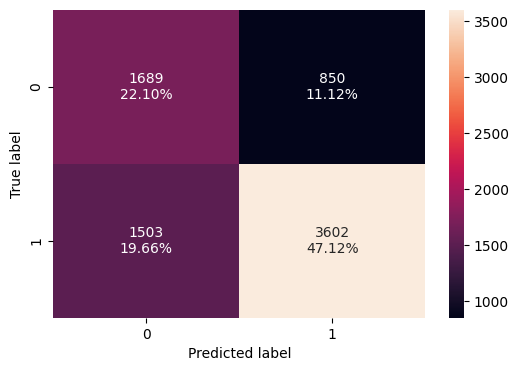

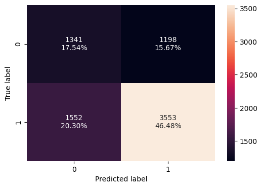

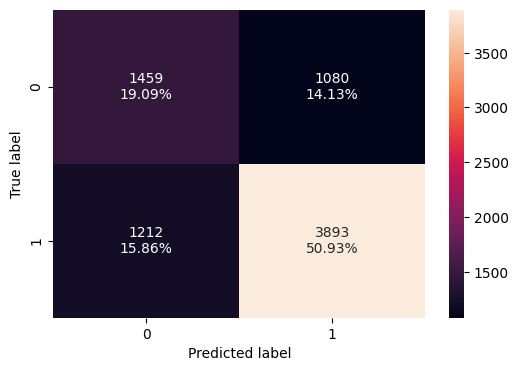

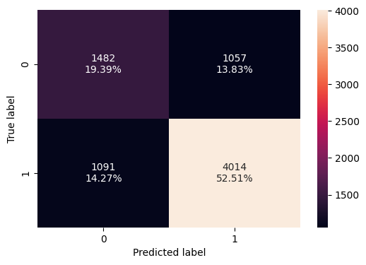

```python
# Applying SMOTE to balance the training data
smote = SMOTE(random_state=42)
X_train_smote, y_train_smote = smote.fit_resample(X_train, y_train)

# Training and evaluating each model with SMOTE-balanced data
results_smote = {}
for name, model in models.items():
    print(f"\nTraining model with SMOTE: {name}")
    model.fit(X_train_smote, y_train_smote)

    # Evaluating on the test set
    test_perf = model_performance_classification_sklearn(model, X_test, y_test)
    results_smote[name] = test_perf

    print("Performance on the test set:")
    display(test_perf)

    # Plotting the confusion matrix
    confusion_matrix_sklearn(model, X_test, y_test)

# Combining results into a single DataFrame
all_results_smote = pd.concat([result.assign(Model=name) for name, result in results_smote.items()])
all_results_smote = all_results_smote[['Model', 'Accuracy', 'Precision', 'Recall', 'F1']]
all_results_smote['Technique'] = 'SMOTE'
```

### Model Building with undersampled data

```
Training model with undersampling: Logistic Regression
Performance on the test set:
```

|  | Accuracy | Recall | Precision | F1 |
| --- | --- | --- | --- | --- |
| 0 | 0.689299 | 0.693046 | 0.814082 | 0.748704 |

```
Training model with undersampling: Decision Tree
Performance on the test set:
```

|  | Accuracy | Recall | Precision | F1 |
| --- | --- | --- | --- | --- |
| 0 | 0.620356 | 0.628599 | 0.761329 | 0.688627 |

```
Training model with undersampling: Random Forest
Performance on the test set:
```

|  | Accuracy | Recall | Precision | F1 |
| --- | --- | --- | --- | --- |
| 0 | 0.678571 | 0.680509 | 0.807907 | 0.738756 |

```
Training model with undersampling: XGBoost
Performance on the test set:
```

|  | Accuracy | Recall | Precision | F1 |
| --- | --- | --- | --- | --- |
| 0 | 0.682234 | 0.688737 | 0.807163 | 0.743262 |

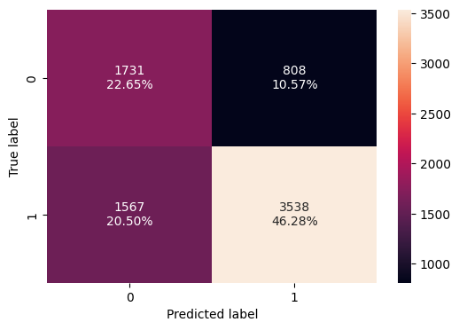

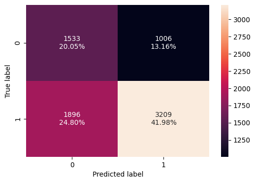

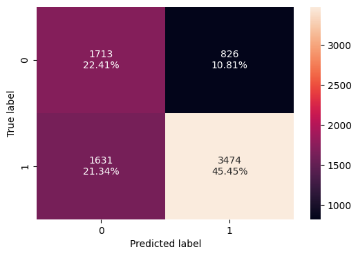

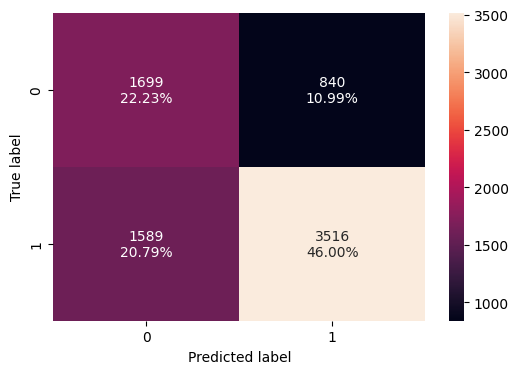

```python
# Applying Random Undersampling to balance the training data
rus = RandomUnderSampler(random_state=42)
X_train_rus, y_train_rus = rus.fit_resample(X_train, y_train)

# Training and evaluating each model with data balanced by undersampling
results_rus = {}
for name, model in models.items():
    print(f"\nTraining model with undersampling: {name}")
    model.fit(X_train_rus, y_train_rus)

    # Evaluating on the test set
    test_perf = model_performance_classification_sklearn(model, X_test, y_test)
    results_rus[name] = test_perf

    print("Performance on the test set:")
    display(test_perf)

    # Plotting the confusion matrix
    confusion_matrix_sklearn(model, X_test, y_test)

# Combining results into a single DataFrame
all_results_rus = pd.concat([result.assign(Model=name) for name, result in results_rus.items()])
all_results_rus = all_results_rus[['Model', 'Accuracy', 'Precision', 'Recall', 'F1']]
all_results_rus['Technique'] = 'Undersampling'
```

**F1-Score Comparison Across Different Techniques**

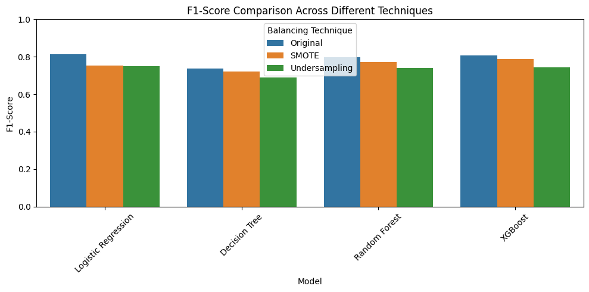

```python
# Adding information about original data
all_results['Technique'] = 'Original'

# Combining all results
combined_results = pd.concat([all_results, all_results_smote, all_results_rus])

# Visualizing comparison of all techniques
plt.figure(figsize=(10, 5))
sns.barplot(data=combined_results, x='Model', y='F1', hue='Technique')
plt.title('F1-Score Comparison Across Different Techniques')
plt.xlabel('Model')
plt.ylabel('F1-Score')
plt.ylim(0, 1)
plt.xticks(rotation=45)
plt.legend(title='Balancing Technique')
plt.tight_layout()
plt.show()
```

## Hyperparameter Tuning

```python
best_model_name = "XGBoost"

# Definindo os hiperparâmetros para ajuste
if best_model_name == "Random Forest":
    param_grid = {
        'n_estimators': [100, 200],
        'max_depth': [None, 10, 20],
        'min_samples_split': [2, 5],
        'min_samples_leaf': [1, 2]
    }
    model = RandomForestClassifier(random_state=42)

elif best_model_name == "XGBoost":
    param_grid = {
        'n_estimators': [100, 200],
        'max_depth': [3, 5],
        'learning_rate': [0.1],
        'subsample': [0.8],
        'colsample_bytree': [0.8]
    }
    model = XGBClassifier(random_state=42)

elif best_model_name == "Logistic Regression":
    param_grid = {
        'C': [0.01, 0.1, 1, 10],
        'penalty': ['l2'],
        'solver': ['lbfgs'],
        'max_iter': [100, 200, 300]
    }
    model = LogisticRegression(random_state=42)

elif best_model_name == "Decision Tree":
    param_grid = {
        'max_depth': [None, 5, 10, 20],
        'min_samples_split': [2, 5, 10],
        'min_samples_leaf': [1, 2, 4],
        'criterion': ['gini', 'entropy']
    }
    model = DecisionTreeClassifier(random_state=42)

else:
    param_grid = {}
    model = models[best_model_name]

# Definindo métricas de avaliação
scorer = {
    'f1': 'f1',
    'recall': 'recall',
    'precision': 'precision',
    'accuracy': 'accuracy'
}

# GridSearchCV para encontrar os melhores hiperparâmetros
grid_search = GridSearchCV(
    estimator=model,
    param_grid=param_grid,
    scoring=scorer,
    refit='f1',  # Usa F1-score para selecionar o melhor modelo
    cv=5,
    verbose=1,
    n_jobs=1
)

# Treinamento
grid_search.fit(X_train, y_train)

# Resultados
print(f"Best parameters: {grid_search.best_params_}")
print(f"Best cross-validation F1-score: {grid_search.best_score_:.4f}")
```

```
Fitting 5 folds for each of 4 candidates, totalling 20 fits
Best parameters: {'colsample_bytree': 0.8, 'learning_rate': 0.1, 'max_depth': 3, 'n_estimators': 100, 'subsample': 0.8}
Best cross-validation F1-score: 0.8233
```

## Model Performances

|  | Accuracy | Recall | Precision | F1 |
| --- | --- | --- | --- | --- |
| 0 | 0.744375 | 0.875612 | 0.772154 | 0.820635 |

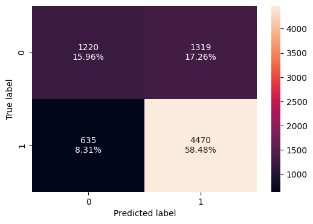

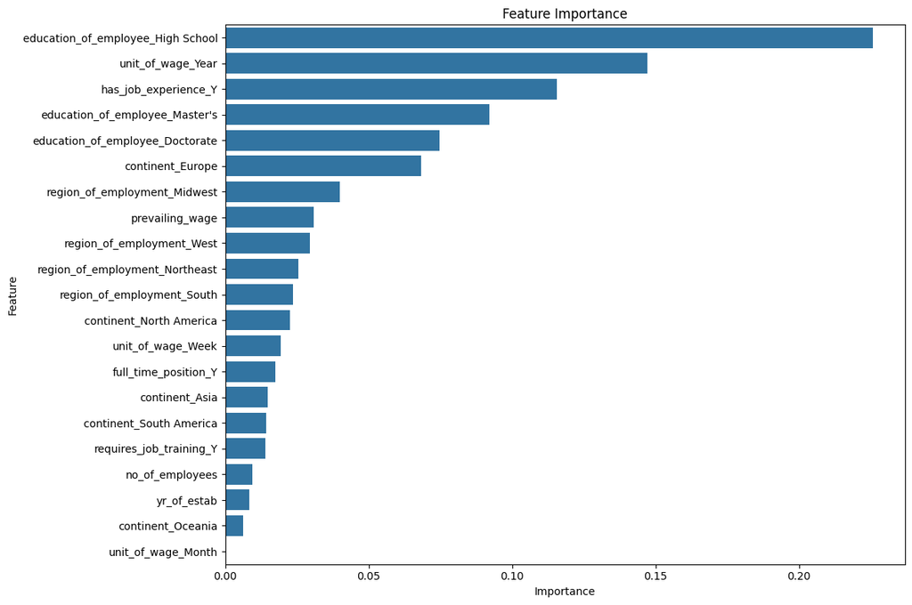

```python
# Evaluating the optimized model on the test set
best_model = grid_search.best_estimator_
best_model_perf = model_performance_classification_sklearn(best_model, X_test, y_test)
display(best_model_perf)

# Confusion matrix for the optimized model
confusion_matrix_sklearn(best_model, X_test, y_test)

# Feature Importance for Logistic Regression
if best_model_name == "Logistic Regression" and hasattr(best_model, 'coef_'):
    feature_importance = pd.DataFrame({
        'Feature': feature_names,
        'Importance': abs(best_model.coef_[0])
    }).sort_values(by='Importance', ascending=False)

    plt.figure(figsize=(12, 8))
    sns.barplot(data=feature_importance, x='Importance', y='Feature')
    plt.title('Feature Importance (Logistic Regression Coefficients)')
    plt.tight_layout()
    plt.show()

elif hasattr(best_model, 'feature_importances_'):
    feature_importance = pd.DataFrame({
        'Feature': feature_names,
        'Importance': best_model.feature_importances_
    }).sort_values(by='Importance', ascending=False)

    plt.figure(figsize=(12, 8))
    sns.barplot(data=feature_importance, x='Importance', y='Feature')
    plt.title('Feature Importance')
    plt.tight_layout()
    plt.show()
```

**Observation:** The top three factors influencing visa certification are the wage unit, the applicant’s educational background, and their professional experience.

## Actionable Insights and Recommendations

1. Ideal Profile for Visa Approval

Our analysis highlights a strong correlation between certain applicant characteristics and a higher likelihood of visa certification. The most favorable applicant profile includes:

- Education Level: Applicants with at least a Bachelor's degree are more likely to be approved, with Master's and Doctorate degrees further increasing the chances.
- Job Experience: Prior work experience significantly boosts approval rates.
- Prevailing Wage: A median prevailing wage around $72,000 is common among approved applications.
- Unit of Wage: Applicants who report yearly wage units tend to have better chances of approval.
- Continent of Origin: Applicants from Europe, Africa, and Asia exhibit higher approval rates.
- Region of Employment in the U.S.:
  - Midwest stands out as the most favorable region for approvals.
  - Educational demand by region:
  - High School graduates: mostly sought in the South, followed by the Northeast.
  - Bachelor's degree: in high demand in the South, then the West.
  - Master's degree: most needed in the Northeast, then the South.
  - Doctorate: more commonly required in the West, followed by the Northeast.
2. Common Profile Associated with Visa Denial

Conversely, the characteristics most associated with visa denial include:

- Education Level: Applicants without a university degree, particularly those who only completed high school.
- Job Experience: Lack of prior job experience.
- Prevailing Wage: Lower median wages around $65,000 are more common among denied cases.
- Unit of Wage: Hourly wage units are more frequently seen in rejected applications.
- Continent of Origin: While visa decisions should not be influenced by nationality, historical data indicates higher rejection rates for applicants from South America, North America, and Oceania.
3. Recommendations for Stakeholders

For Visa Applicants:

- Invest in Higher Education: A Bachelor's degree is the minimum recommended level; advanced degrees can strengthen applications.
- Gain Relevant Job Experience: Even a few years of experience can significantly improve approval odds.
- Negotiate a Competitive Wage: Aim for a prevailing wage closer to or above the $72k benchmark.
- Prefer Yearly Wage Contracts: Annual wage units align better with successful cases.

For Employers:

- Offer Competitive Salaries: Align offered wages with or above market standards.
- Support Skilled Workers: Prioritize candidates with experience and academic credentials suited to the role.
- Be Strategic with Job Locations: Consider posting positions in regions with higher approval trends.

For the OFLC (Office of Foreign Labor Certification):

- Standardize Application Review Criteria: Reducing subjectivity in visa processing could enhance fairness.
- Provide Clearer Application Guidelines: Help both employers and applicants understand key approval factors.
- Adopt Predictive Modeling Tools: Use machine learning models as a first-pass screening tool to streamline the review process.

Further Data Collection Needs:

To enhance predictive accuracy, it is recommended to gather more detailed information such as:

- From Employers: Industry sector, company size, and detailed salary breakdowns.
- From Applicants: Field of specialization, total years of experience, and certifications or technical skills.